# M05-2-Application: Data Wrangling with Tidyverse in R

Author

Dia Kaewdee

Published

June 28, 2026

```r
# Setup

# Install these packages only if needed.
#install.packages(c("tidyverse", "nycflights13", "gt", "gtExtras"))

library(tidyverse)
library(nycflights13)
library(gt)
library(gtExtras)
```

# 1 Ex 1

## 1.1 1.1

Using the Tidyverse library, set the built-in `airquality` dataset to a tibble format named `air.tib`. Confirm that the operation was successful. Next, create a new data frame from `air.tib` and assign `air.df` to the data frame. Confirm that the operation was successful.

```r
# Convert the built-in airquality data to a tibble.
air.tib <- as_tibble(airquality)

# Print the tibble to confirm it worked.
air.tib
```

```
# A tibble: 153 × 6
   Ozone Solar.R  Wind  Temp Month   Day
   <int>   <int> <dbl> <int> <int> <int>
 1    41     190   7.4    67     5     1
 2    36     118   8      72     5     2
 3    12     149  12.6    74     5     3
 4    18     313  11.5    62     5     4
 5    NA      NA  14.3    56     5     5
 6    28      NA  14.9    66     5     6
 7    23     299   8.6    65     5     7
 8    19      99  13.8    59     5     8
 9     8      19  20.1    61     5     9
10    NA     194   8.6    69     5    10
# ℹ 143 more rows
```

```r
# Convert the tibble back into a regular data frame.
air.df <- as.data.frame(air.tib)

# Print the data frame to confirm it worked.
air.df
```

```
    Ozone Solar.R Wind Temp Month Day
1      41     190  7.4   67     5   1
2      36     118  8.0   72     5   2
3      12     149 12.6   74     5   3
4      18     313 11.5   62     5   4
5      NA      NA 14.3   56     5   5
6      28      NA 14.9   66     5   6
7      23     299  8.6   65     5   7
8      19      99 13.8   59     5   8
9       8      19 20.1   61     5   9
10     NA     194  8.6   69     5  10
11      7      NA  6.9   74     5  11
12     16     256  9.7   69     5  12
13     11     290  9.2   66     5  13
14     14     274 10.9   68     5  14
```

[output cut: 139 more lines]

## 1.2 1.2

Using the tibble created earlier, find the Ozone amount when the temperature was 97. Show this by both subsetting the entire row and pinpointing the Ozone element only. Also, for both ways, use Base R approach as well as Tidyverse approach.

```r
# Base R: show the entire row where Temp equals 97.
air.tib[air.tib$Temp == 97, ]
```

```
# A tibble: 1 × 6
  Ozone Solar.R  Wind  Temp Month   Day
  <int>   <int> <dbl> <int> <int> <int>
1    76     203   9.7    97     8    28
```

```r
# Base R: show only the Ozone value where Temp equals 97.
air.tib[air.tib$Temp == 97, "Ozone"]
```

```
# A tibble: 1 × 1
  Ozone
  <int>
1    76
```

```r
# Tidyverse: show the entire row where Temp equals 97.
air.tib |> filter(Temp == 97)
```

```
# A tibble: 1 × 6
  Ozone Solar.R  Wind  Temp Month   Day
  <int>   <int> <dbl> <int> <int> <int>
1    76     203   9.7    97     8    28
```

```r
# Tidyverse: show only the Ozone value where Temp equals 97.
air.tib |> filter(Temp == 97) |> select(Ozone)
```

```
# A tibble: 1 × 1
  Ozone
  <int>
1    76
```

# 2 Ex 2

Use the `flights` data for this exercise.

## 2.1 2.1

Select only the top 10 worst arrival delays for each day for each month for each year. Using the subset of the data, calculate the average delay for each month regardless of the dates or years.

```r
# Group by year, month, and day first.
# Then select the 10 worst arrival delays for each day.
worst_daily_delays <- flights |>
  filter(!is.na(arr_delay)) |> group_by(year, month, day) |>
  slice_max(order_by = arr_delay, n = 10, with_ties = FALSE) |>
  ungroup()

# Print the subset to confirm it worked.
worst_daily_delays
```

```
# A tibble: 3,650 × 19
    year month   day dep_time sched_dep_time dep_delay arr_time sched_arr_time
   <int> <int> <int>    <int>          <int>     <dbl>    <int>          <int>
 1  2013     1     1      848           1835       853     1001           1950
 2  2013     1     1     2343           1724       379      314           1938
 3  2013     1     1     1815           1325       290     2120           1542
 4  2013     1     1     1842           1422       260     1958           1535
 5  2013     1     1     2115           1700       255     2330           1920
 6  2013     1     1     2205           1720       285       46           2040
 7  2013     1     1     2006           1630       216     2230           1848
 8  2013     1     1     2312           2000       192       21           2110
 9  2013     1     1     1942           1705       157     2124           1830
10  2013     1     1     1938           1703       155     2109           1823
# ℹ 3,640 more rows
# ℹ 11 more variables: arr_delay <dbl>, carrier <chr>, flight <int>,
#   tailnum <chr>, origin <chr>, dest <chr>, air_time <dbl>, distance <dbl>,
#   hour <dbl>, minute <dbl>, time_hour <dttm>
```

```r
# Calculate the average of those worst delays by month.
monthly_worst_delay_avg <- worst_daily_delays |>
  group_by(month) |>
  summarize(
    avg_arr_delay = mean(arr_delay, na.rm = TRUE),
    .groups = "drop"
    )

# Print the monthly summary.
monthly_worst_delay_avg
```

```
# A tibble: 12 × 2
   month avg_arr_delay
   <int>         <dbl>
 1     1          200.
 2     2          199.
 3     3          202.
 4     4          220.
 5     5          202.
 6     6          249.
 7     7          254.
 8     8          195.
 9     9          166.
10    10          161.
11    11          162.
12    12          225.
```

## 2.2 2.2

Visualize the data that shows average delays each month. Style the chart appropriately to make the chart presentable.

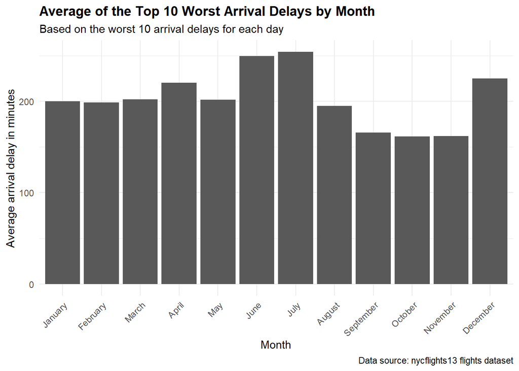

```r
monthly_worst_delay_avg |>
  mutate(month = factor(month, levels = 1:12, labels = month.name)) |>
  ggplot(aes(x = month, y = avg_arr_delay)) +
  geom_col() +
  labs(
    title = "Average of the Top 10 Worst Arrival Delays by Month",
    subtitle = "Based on the worst 10 arrival delays for each day",
    x = "Month",
    y = "Average arrival delay in minutes",
    caption = "Data source: nycflights13 flights dataset"
  ) +
  theme_minimal() +
  theme(
    axis.text.x = element_text(angle = 45, hjust = 1),
    plot.title = element_text(face = "bold")
  )
```

## 2.3 2.3

Describe what you learned from the data about delays.

**Note**

It looks like some months have much higher delays than others. Summer and winter seem to have the biggest delays, although this chart by itself doesn’t explain exactly why.

# 3 Ex 3

The final goal of this exercise is to visualize the data. To do so, I first need to understand the data and then reshape it into a format that works better for visualization.

## 3.1 3.1

Take a look at the built-in data frame `relig_income` from the `tidyr` package. Perform some built-in functions that will help you understand the data, such as type of data, size, missing values, and variables.

```r
# Print the data to get a first look.
relig_income
```

```
# A tibble: 18 × 11
   religion `<$10k` `$10-20k` `$20-30k` `$30-40k` `$40-50k` `$50-75k` `$75-100k`
   <chr>      <dbl>     <dbl>     <dbl>     <dbl>     <dbl>     <dbl>      <dbl>
 1 Agnostic      27        34        60        81        76       137        122
 2 Atheist       12        27        37        52        35        70         73
 3 Buddhist      27        21        30        34        33        58         62
 4 Catholic     418       617       732       670       638      1116        949
 5 Don’t k…      15        14        15        11        10        35         21
 6 Evangel…     575       869      1064       982       881      1486        949
 7 Hindu          1         9         7         9        11        34         47
 8 Histori…     228       244       236       238       197       223        131
 9 Jehovah…      20        27        24        24        21        30         15
10 Jewish        19        19        25        25        30        95         69
11 Mainlin…     289       495       619       655       651      1107        939
12 Mormon        29        40        48        51        56       112         85
13 Muslim         6         7         9        10         9        23         16
14 Orthodox      13        17        23        32        32        47         38
15 Other C…       9         7        11        13        13        14         18
16 Other F…      20        33        40        46        49        63         46
17 Other W…       5         2         3         4         2         7          3
18 Unaffil…     217       299       374       365       341       528        407
# ℹ 3 more variables: `$100-150k` <dbl>, `>150k` <dbl>,
#   `Don't know/refused` <dbl>
```

```r
# Check the structure of the data.
str(relig_income)
```

```
tibble [18 × 11] (S3: tbl_df/tbl/data.frame)
 $ religion          : chr [1:18] "Agnostic" "Atheist" "Buddhist" "Catholic" ...
 $ <$10k             : num [1:18] 27 12 27 418 15 575 1 228 20 19 ...
 $ $10-20k           : num [1:18] 34 27 21 617 14 869 9 244 27 19 ...
 $ $20-30k           : num [1:18] 60 37 30 732 15 ...
 $ $30-40k           : num [1:18] 81 52 34 670 11 982 9 238 24 25 ...
 $ $40-50k           : num [1:18] 76 35 33 638 10 881 11 197 21 30 ...
 $ $50-75k           : num [1:18] 137 70 58 1116 35 ...
 $ $75-100k          : num [1:18] 122 73 62 949 21 949 47 131 15 69 ...
 $ $100-150k         : num [1:18] 109 59 39 792 17 723 48 81 11 87 ...
 $ >150k             : num [1:18] 84 74 53 633 18 414 54 78 6 151 ...
 $ Don't know/refused: num [1:18] 96 76 54 1489 116 ...
```

```r
# Check the dimensions.
dim(relig_income)
```

```
[1] 18 11
```

```r
# Check the variable names.
names(relig_income)
```

```
 [1] "religion"           "<$10k"              "$10-20k"
 [4] "$20-30k"            "$30-40k"            "$40-50k"
 [7] "$50-75k"            "$75-100k"           "$100-150k"
[10] ">150k"              "Don't know/refused"
```

```r
# Count missing values in each column.
relig_income |>
  summarize(across(everything(), ~ sum(is.na(.))))
```

```
# A tibble: 1 × 11
  religion `<$10k` `$10-20k` `$20-30k` `$30-40k` `$40-50k` `$50-75k` `$75-100k`
     <int>   <int>     <int>     <int>     <int>     <int>     <int>      <int>
1        0       0         0         0         0         0         0          0
# ℹ 3 more variables: `$100-150k` <int>, `>150k` <int>,
#   `Don't know/refused` <int>
```

The `relig_income` data set is a tibble with 18 rows and 11 variables. Each row represents a religion category, and the columns after religion represent different income brackets. I don’tt see missing values in the data from the missing value check.

## 3.2 3.2

Look up the help documentation for `relig_income`.

```r
# Open the help documentation for the data set.
help(relig_income)
```

The help documentation explains that `relig_income` contains counts based on religion and income categories. The `religion` column identifies the religious group, and the other columns represent income ranges. The values in those income columns are counts. This helped me understand that the numbers are frequencies, not actual income amounts for individual people.

## 3.3 3.3

Think about the relationships among the variables you want to visualize. One potential idea is to show what the frequency of income brackets looks like by religion. Does the current data allow you to support your goal? Why or why not? If the data does not support the goal, how should the data be reshaped?

The current data gives the information needed, but it is not in the best shape for the visualization yet. The income brackets are stored as column names instead of being values in one income column. Because of that, the data is wider than it needs to be. To make it tidy, each row should represent one religion and one income bracket, with the count in a separate column. Reshaping the data into a longer format makes it easier to use `ggplot()` because income can become one variable and count can become another variable.

## 3.4 3.4

Reshape the data. Draw a plot that shows income distribution by religion.

```r
# Reshape the data from wide to long format.
relig_income_longer <- relig_income |>
  pivot_longer(
    cols = -religion,
    names_to = "income",
    values_to = "count"
  ) |>
  filter(income != "Don't know/refused")

# Print the reshaped data to confirm it worked.
relig_income_longer
```

```
# A tibble: 162 × 3
   religion income    count
   <chr>    <chr>     <dbl>
 1 Agnostic <$10k        27
 2 Agnostic $10-20k      34
 3 Agnostic $20-30k      60
 4 Agnostic $30-40k      81
 5 Agnostic $40-50k      76
 6 Agnostic $50-75k     137
 7 Agnostic $75-100k    122
 8 Agnostic $100-150k   109
 9 Agnostic >150k        84
10 Atheist  <$10k        12
# ℹ 152 more rows
```

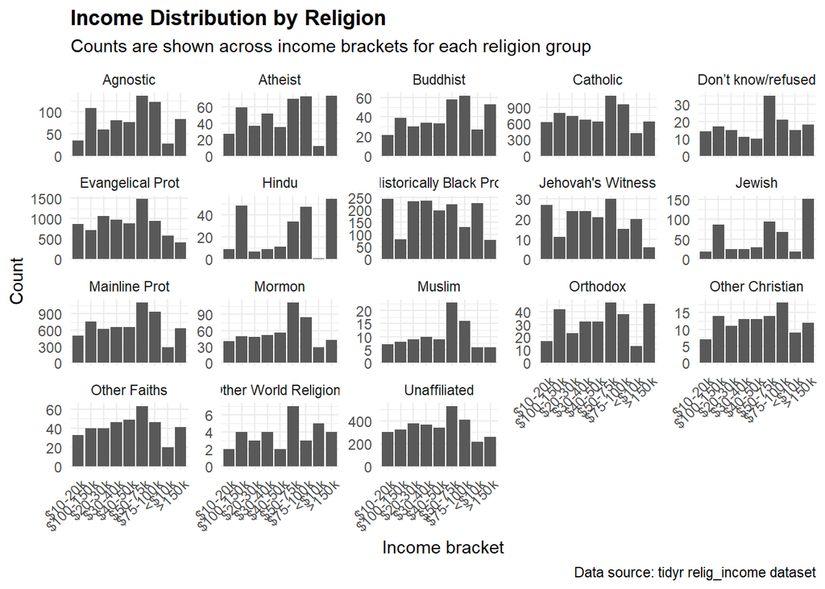

```r
# Create a plot showing income distribution by religion.
relig_income_longer |>
  ggplot(aes(x = income, y = count)) +
  geom_col() +
  facet_wrap(~ religion, scales = "free_y") +
  labs(
    title = "Income Distribution by Religion",
    subtitle = "Counts are shown across income brackets for each religion group",
    x = "Income bracket",
    y = "Count",
    caption = "Data source: tidyr relig_income dataset"
  ) +
  theme_minimal() +
  theme(
    axis.text.x = element_text(angle = 45, hjust = 1),
    plot.title = element_text(face = "bold")
  )
```

The reshaped version is much easier to graph because income is now one column instead of several separate columns. I used facets so each religion has its own small chart. This makes the chart easier to read than trying to put every religion into one crowded graph.

## 3.5 3.5

Redo 3.4 using one long chain of code from the first step to the last.

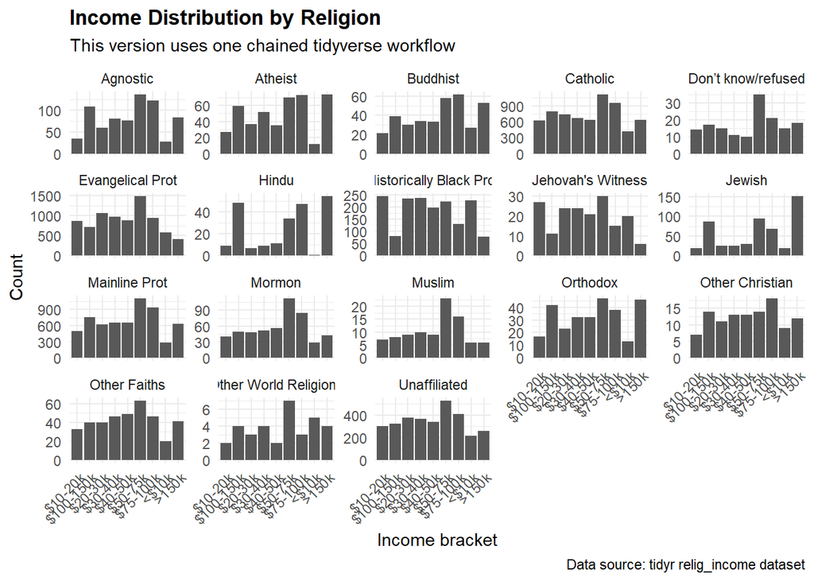

```r
relig_income |>
  pivot_longer(
    cols = -religion,
    names_to = "income",
    values_to = "count"
  ) |>
  filter(income != "Don't know/refused") |>
  ggplot(aes(x = income, y = count)) +
  geom_col() +
  facet_wrap(~ religion, scales = "free_y") +
  labs(
    title = "Income Distribution by Religion",
    subtitle = "This version uses one chained tidyverse workflow",
    x = "Income bracket",
    y = "Count",
    caption = "Data source: tidyr relig_income dataset"
  ) +
  theme_minimal() +
  theme(
    axis.text.x = element_text(angle = 45, hjust = 1),
    plot.title = element_text(face = "bold")
  )
```

# 4 Ex 4

## 4.1 4.1

Take a look at the built-in data frame `us_rent_income` from the `tidyr` package. Perform some built-in functions that will help you understand the data.

```r
# Print the data to get a first look.
us_rent_income
```

```
# A tibble: 104 × 5
   GEOID NAME       variable estimate   moe
   <chr> <chr>      <chr>       <dbl> <dbl>
 1 01    Alabama    income      24476   136
 2 01    Alabama    rent          747     3
 3 02    Alaska     income      32940   508
 4 02    Alaska     rent         1200    13
 5 04    Arizona    income      27517   148
 6 04    Arizona    rent          972     4
 7 05    Arkansas   income      23789   165
 8 05    Arkansas   rent          709     5
 9 06    California income      29454   109
10 06    California rent         1358     3
# ℹ 94 more rows
```

```r
# Check the structure.
str(us_rent_income)
```

```
tibble [104 × 5] (S3: tbl_df/tbl/data.frame)
 $ GEOID   : chr [1:104] "01" "01" "02" "02" ...
 $ NAME    : chr [1:104] "Alabama" "Alabama" "Alaska" "Alaska" ...
 $ variable: chr [1:104] "income" "rent" "income" "rent" ...
 $ estimate: num [1:104] 24476 747 32940 1200 27517 ...
 $ moe     : num [1:104] 136 3 508 13 148 4 165 5 109 3 ...
```

```r
# Check the dimensions.
dim(us_rent_income)
```

```
[1] 104   5
```

```r
# Check the variable names.
names(us_rent_income)
```

```
[1] "GEOID"    "NAME"     "variable" "estimate" "moe"
```

```r
# Count missing values in each column.
us_rent_income |>
  summarize(across(everything(), ~ sum(is.na(.))))
```

```
# A tibble: 1 × 5
  GEOID  NAME variable estimate   moe
  <int> <int>    <int>    <int> <int>
1     0     0        0        1     1
```

## 4.2 4.2

Type code that will show the description of the data in the help documentation. Then read the description of the variables.

```r
# Open the help documentation for this data set.
help(us_rent_income)
```

The help page explains that this data comes from the American Community Survey. `GEOID` is the geographic ID, and `NAME` is the state name. The `variable` column shows whether the row is about income or rent. The `estimate` column gives the estimated value, and `moe` is the margin of error.

## 4.3 4.3

Think about the relationship between income and rent across the states. Does the current data shape support the visualization goal? Why or why not?

The current data has the information needed, but it is not shaped in the easiest way for a scatterplot. Right now, income and rent are both stored in the `variable` column, so they are not separate columns yet. To graph the relationship between income and rent, each state should have one row with separate income and rent columns. Reshaping the data wider makes the relationship much easier to visualize.

## 4.4 4.4

Reshape the data. Draw a plot that shows the relationship between income and rent across the states.

```r
# Reshape the data so income and rent become separate columns.
us_rent_income_wider <- us_rent_income |>
  pivot_wider(
    names_from = variable,
    values_from = c(estimate, moe)
  )

# Print the reshaped data to confirm it worked.
us_rent_income_wider
```

```
# A tibble: 52 × 6
   GEOID NAME                 estimate_income estimate_rent moe_income moe_rent
   <chr> <chr>                          <dbl>         <dbl>      <dbl>    <dbl>
 1 01    Alabama                        24476           747        136        3
 2 02    Alaska                         32940          1200        508       13
 3 04    Arizona                        27517           972        148        4
 4 05    Arkansas                       23789           709        165        5
 5 06    California                     29454          1358        109        3
 6 08    Colorado                       32401          1125        109        5
 7 09    Connecticut                    35326          1123        195        5
 8 10    Delaware                       31560          1076        247       10
 9 11    District of Columbia           43198          1424        681       17
10 12    Florida                        25952          1077         70        3
# ℹ 42 more rows
```

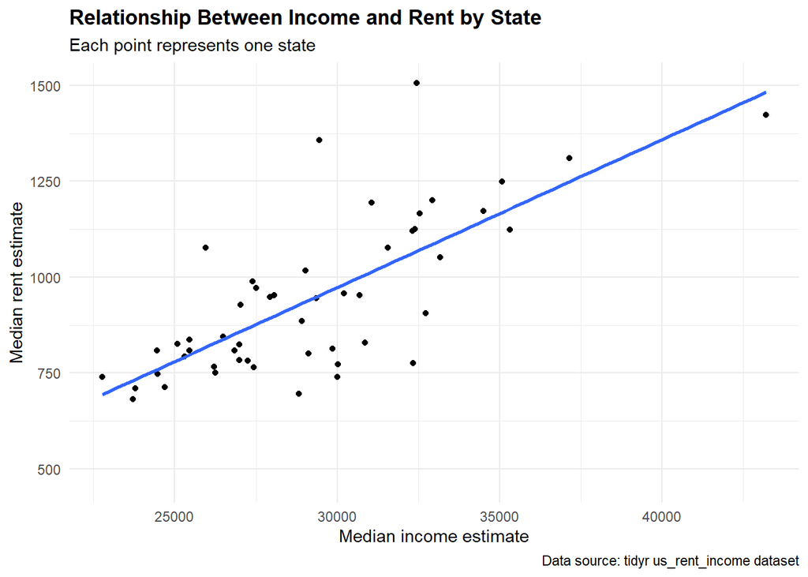

```r
# Visualize the relationship between income and rent.
us_rent_income_wider |>
  ggplot(aes(x = estimate_income, y = estimate_rent)) +
  geom_point() +
  geom_smooth(method = "lm", se = FALSE) +
  labs(
    title = "Relationship Between Income and Rent by State",
    subtitle = "Each point represents one state",
    x = "Median income estimate",
    y = "Median rent estimate",
    caption = "Data source: tidyr us_rent_income dataset"
  ) +
  theme_minimal() +
  theme(
    plot.title = element_text(face = "bold")
  )
```

The scatterplot suggests a positive relationship between income and rent. States with higher median income also tend to have higher median rent. This makes sense because places with higher incomes often have higher housing costs too. I would still describe this as an association, not proof that one variable causes the other.

## 4.5 4.5

Repeat what you did in 4.4, from tidying the data to visualizing the data, in one chain of code using the Tidyverse way.

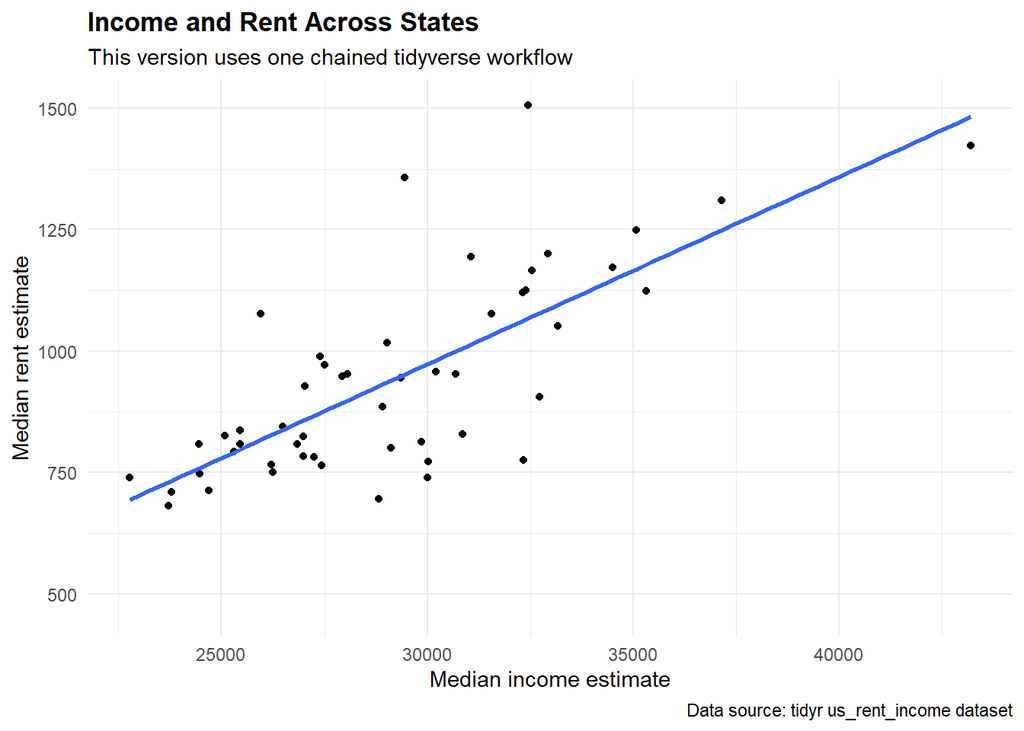

```r
us_rent_income |>
  pivot_wider(
    names_from = variable,
    values_from = c(estimate, moe)
  ) |>
  ggplot(aes(x = estimate_income, y = estimate_rent)) +
  geom_point() +
  geom_smooth(method = "lm", se = FALSE) +
  labs(
    title = "Income and Rent Across States",
    subtitle = "This version uses one chained tidyverse workflow",
    x = "Median income estimate",
    y = "Median rent estimate",
    caption = "Data source: tidyr us_rent_income dataset"
  ) +
  theme_minimal() +
  theme(
    plot.title = element_text(face = "bold")
  )
```

```r
# Print the reshaped data too, so the wrangling result is visible.
us_rent_income |>
  pivot_wider(
    names_from = variable,
    values_from = c(estimate, moe)
  )
```

```
# A tibble: 52 × 6
   GEOID NAME                 estimate_income estimate_rent moe_income moe_rent
   <chr> <chr>                          <dbl>         <dbl>      <dbl>    <dbl>
 1 01    Alabama                        24476           747        136        3
 2 02    Alaska                         32940          1200        508       13
 3 04    Arizona                        27517           972        148        4
 4 05    Arkansas                       23789           709        165        5
 5 06    California                     29454          1358        109        3
 6 08    Colorado                       32401          1125        109        5
 7 09    Connecticut                    35326          1123        195        5
 8 10    Delaware                       31560          1076        247       10
 9 11    District of Columbia           43198          1424        681       17
10 12    Florida                        25952          1077         70        3
# ℹ 42 more rows
```

# 5 Ex 5

Run the code below.

```r
mba <- data.frame(
  player = c("A", "A", "B", "B", "C", "C"),
  year = c(1, 2, 1, 2, 1, 2),
  stats = c("22/2/3", "29/3/4", "18/6/7", "11/1/2", "12/1/1", "19/2/4")
)

# Print the data to confirm it was created.
mba
```

```
  player year  stats
1      A    1 22/2/3
2      A    2 29/3/4
3      B    1 18/6/7
4      B    2 11/1/2
5      C    1 12/1/1
6      C    2 19/2/4
```

## 5.1 5.1

Separate the number of the `stats` column into `points`, `assists`, and `steals`. Assign this data frame to a new name, `mba_sep`. Print out the data set.

```r
# Separate the stats column into three columns.
mba_sep <- mba |>
  separate(
    col = stats,
    into = c("points", "assists", "steals"),
    sep = "/",
    convert = TRUE
  )

# Print the separated data.
mba_sep
```

```
  player year points assists steals
1      A    1     22       2      3
2      A    2     29       3      4
3      B    1     18       6      7
4      B    2     11       1      2
5      C    1     12       1      1
6      C    2     19       2      4
```

## 5.2 5.2

Reverse the last question by uniting three columns: `points`, `assists`, and `steals`, into one column. Assign `mba_uni` to the data frame. Then confirm the work by printing it out.

```r
# Unite the three stat columns back into one column.
mba_uni <- mba_sep |>
  unite(
    col = "stats",
    points,
    assists,
    steals,
    sep = "/"
  )

# Print the united data.
mba_uni
```

```
  player year  stats
1      A    1 22/2/3
2      A    2 29/3/4
3      B    1 18/6/7
4      B    2 11/1/2
5      C    1 12/1/1
6      C    2 19/2/4
```

# 6 Ex 6

Use the `flights` data.

## 6.1 6.1

Filter the data by including only the flights that were not canceled. For each day, calculate the first and last departure times from NYC airport. Then, for each month, select one day such that the first flight departure was the latest for the month. Show the results in descending order of `first_dep` in a table using `gt`.

```r
# Keep only flights that have a departure time.
# These are treated as flights that were not canceled.
daily_departures <- flights |>
  filter(!is.na(dep_time)) |>
  group_by(year, month, day) |>
  summarize(
    first_dep = min(dep_time),
    last_dep = max(dep_time),
    n = n(),
    .groups = "drop"
  )

# Print the daily summary to confirm it worked.
daily_departures
```

```
# A tibble: 365 × 6
    year month   day first_dep last_dep     n
   <int> <int> <int>     <int>    <int> <int>
 1  2013     1     1       517     2356   838
 2  2013     1     2        42     2354   935
 3  2013     1     3        32     2349   904
 4  2013     1     4        25     2358   909
 5  2013     1     5        14     2357   717
 6  2013     1     6        16     2355   831
 7  2013     1     7        49     2359   930
 8  2013     1     8       454     2351   895
 9  2013     1     9         2     2252   897
10  2013     1    10         3     2320   929
# ℹ 355 more rows
```

```r
# Select the day in each month where the first departure was latest.
latest_first_departure <- daily_departures |>
  group_by(month) |>
  slice_max(order_by = first_dep, n = 1, with_ties = FALSE) |>
  ungroup() |>
  arrange(desc(first_dep))

# Print the result before making the table.
latest_first_departure
```

```
# A tibble: 12 × 6
    year month   day first_dep last_dep     n
   <int> <int> <int>     <int>    <int> <int>
 1  2013     2     9       901     2358   291
 2  2013     1    20       525     2356   782
 3  2013     9    29       521     2356   911
 4  2013    10     6       519     2346   914
 5  2013    11     3       519     2358   900
 6  2013     3     3       509     2353   910
 7  2013    12    18       500     2358   953
 8  2013     5    29       457     2352   969
 9  2013     6    15       456     2356   795
10  2013     4    30       455     2351   958
11  2013     8    31       455     2359   676
12  2013     7     5        38     2358   819
```

```r
# Create a nicer table with gt.
latest_first_departure |>
  gt() |>
  tab_header(
    title = "Latest First Departure Time by Month",
    subtitle = "One day selected per month from non-canceled flights"
  ) |>
  cols_label(
    year = "Year",
    month = "Month",
    day = "Day",
    first_dep = "First Departure",
    last_dep = "Last Departure",
    n = "Number of Flights"
  )
```

Latest First Departure Time by Month

One day selected per month from non-canceled flights

| Year | Month | Day | First Departure | Last Departure | Number of Flights |
| --- | --- | --- | --- | --- | --- |
| 2013 | 2 | 9 | 901 | 2358 | 291 |
| 2013 | 1 | 20 | 525 | 2356 | 782 |
| 2013 | 9 | 29 | 521 | 2356 | 911 |
| 2013 | 10 | 6 | 519 | 2346 | 914 |
| 2013 | 11 | 3 | 519 | 2358 | 900 |
| 2013 | 3 | 3 | 509 | 2353 | 910 |
| 2013 | 12 | 18 | 500 | 2358 | 953 |
| 2013 | 5 | 29 | 457 | 2352 | 969 |
| 2013 | 6 | 15 | 456 | 2356 | 795 |
| 2013 | 4 | 30 | 455 | 2351 | 958 |
| 2013 | 8 | 31 | 455 | 2359 | 676 |
| 2013 | 7 | 5 | 38 | 2358 | 819 |

## 6.2 6.2

Wrangle the data to find out the top 5 destinations to which carriers flew the most. Print the data in a nice table. Does the finding make sense? Discuss the outcome.

```r
# Count carrier and destination combinations.
top_destinations <- flights |>
  filter(!is.na(dest), !is.na(carrier)) |>
  count(carrier, dest, sort = TRUE) |>
  slice_max(order_by = n, n = 5)

# Print the result.
top_destinations
```

```
# A tibble: 5 × 3
  carrier dest      n
  <chr>   <chr> <int>
1 DL      ATL   10571
2 US      CLT    8632
3 AA      DFW    7257
4 AA      MIA    7234
5 UA      ORD    6984
```

```r
# Display the result as a gt table.
top_destinations |>
  gt() |>
  tab_header(
    title = "Top 5 Carrier and Destination Combinations",
    subtitle = "Based on number of flights in the nycflights13 data"
  ) |>
  cols_label(
    carrier = "Carrier",
    dest = "Destination",
    n = "Number of Flights"
  )
```

Top 5 Carrier and Destination Combinations

Based on number of flights in the nycflights13 data

| Carrier | Destination | Number of Flights |
| --- | --- | --- |
| DL | ATL | 10571 |
| US | CLT | 8632 |
| AA | DFW | 7257 |
| AA | MIA | 7234 |
| UA | ORD | 6984 |

The finding makes sense because the busiest routes from New York airports are usually connected to major cities and common travel destinations. Since this data only includes flights leaving NYC, it is not surprising that the top results are specific carrier and destination combinations rather than just destinations by themselves. The table helps show which routes were used the most in this data set.

# 7 Ex 7

Using the data frame `air.tib`, find out how many missing values exist in the column `Solar.R` and what percent of the record the missing values account for. Next, create a variable called `Solar_Mean` and assign the mean of the column `Solar.R` to it. Finally, replace all the missing values in `Solar.R` with `Solar_Mean`. Confirm that there are no more missing values in this column.

```r
# Count missing values in Solar.R and calculate the percent missing.
solar_missing_summary <- air.tib |>
  summarize(
    missing_values = sum(is.na(Solar.R)),
    total_records = n(),
    percent_missing = missing_values / total_records * 100
  )

# Print the missing value summary.
solar_missing_summary
```

```
# A tibble: 1 × 3
  missing_values total_records percent_missing
           <int>         <int>           <dbl>
1              7           153            4.58
```

```r
# Calculate the mean of Solar.R while ignoring missing values.
Solar_Mean <- mean(air.tib$Solar.R, na.rm = TRUE)

# Print the mean to confirm it worked.
Solar_Mean
```

```
[1] 185.9315
```

```r
# Replace missing Solar.R values with the mean.
air.tib <- air.tib |>
  mutate(
    Solar.R = if_else(is.na(Solar.R), Solar_Mean, Solar.R)
  )

# Confirm that there are no more missing values in Solar.R.
air.tib |>
  summarize(
    missing_values_after = sum(is.na(Solar.R))
  )
```

```
# A tibble: 1 × 1
  missing_values_after
                 <int>
1                    0
```

```r
# Print the updated data.
air.tib
```

```
# A tibble: 153 × 6
   Ozone Solar.R  Wind  Temp Month   Day
   <int>   <dbl> <dbl> <int> <int> <int>
 1    41    190    7.4    67     5     1
 2    36    118    8      72     5     2
 3    12    149   12.6    74     5     3
 4    18    313   11.5    62     5     4
 5    NA    186.  14.3    56     5     5
 6    28    186.  14.9    66     5     6
 7    23    299    8.6    65     5     7
 8    19     99   13.8    59     5     8
 9     8     19   20.1    61     5     9
10    NA    194    8.6    69     5    10
# ℹ 143 more rows
```

There were missing values in the `Solar.R` column, so I replaced them with the mean of the available `Solar.R` values. This is a simple way to keep the rows in the data set instead of deleting them. After the replacement, the missing value check confirms that there are no missing values left in that column.

# 8 Ex 8

Use the `air.tib` data frame. The goal is to visualize the monthly total temperature with a barplot with Month on the y-axis and total temperature on the x-axis. Do the appropriate wrangling and visualization in one chain of code.

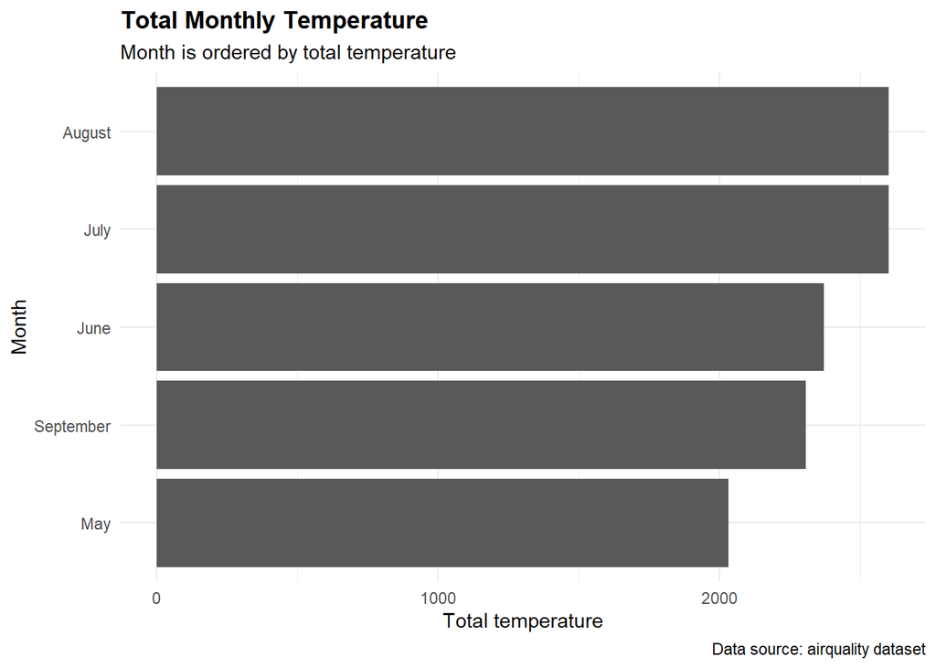

```r
air.tib |>
  count(Month, wt = Temp) |>
  mutate(
    Month = case_when(
      Month == 5 ~ "May",
      Month == 6 ~ "June",
      Month == 7 ~ "July",
      Month == 8 ~ "August",
      Month == 9 ~ "September"
    ),
    Month = factor(Month),
    Month = fct_reorder(Month, n, .desc = FALSE)
  ) |>
  ggplot(aes(x = n, y = Month)) +
  geom_col() +
  labs(
    title = "Total Monthly Temperature",
    subtitle = "Month is ordered by total temperature",
    x = "Total temperature",
    y = "Month",
    caption = "Data source: airquality dataset"
  ) +
  theme_minimal() +
  theme(
    plot.title = element_text(face = "bold")
  )
```

The chart shows the total temperature for each month after grouping and summarizing the data. July and August had the highest totals, which matches what I expected. This exercise helped me understand how multiple tidyverse functions can work together in a single pipeline.

# 9 Ex 9

Using the `air.tib` data frame, group the data set by Month. Next, find out the maximum temperature for each month and display the result. Then, pipe the wrangled data into `ggplot()` and draw an appropriate chart.

```r
# Find the maximum temperature for each month.
monthly_max_temp <- air.tib |>
  group_by(Month) |>
  summarize(
    max_temp = max(Temp),
    .groups = "drop"
  ) |>
  mutate(
    Month = case_when(
      Month == 5 ~ "May",
      Month == 6 ~ "June",
      Month == 7 ~ "July",
      Month == 8 ~ "August",
      Month == 9 ~ "September"
    ),
    Month = fct_reorder(Month, max_temp, .desc = FALSE)
  )

# Print the result.
monthly_max_temp
```

```
# A tibble: 5 × 2
  Month     max_temp
  <fct>        <int>
1 May             81
2 June            93
3 July            92
4 August          97
5 September       93
```

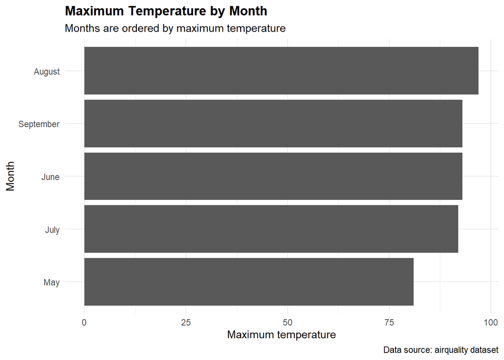

```r
# Visualize the maximum temperature by month.
monthly_max_temp |>
  ggplot(aes(x = max_temp, y = Month)) +
  geom_col() +
  labs(
    title = "Maximum Temperature by Month",
    subtitle = "Months are ordered by maximum temperature",
    x = "Maximum temperature",
    y = "Month",
    caption = "Data source: airquality dataset"
  ) +
  theme_minimal() +
  theme(
    plot.title = element_text(face = "bold")
  )
```

The chart shows that the hottest maximum temperatures happen in the summer months. This makes sense because the data covers warmer months from May through September. The ordered bar chart makes it easier to compare the months instead of reading them only in calendar order.

# 10 Ex 10

Using the pipe operator on the tibble `air.tib`, create a new column called `temp_wind`, which is the division of `Temp` by the `Wind` column. Investigate the relationship between Ozone amount and `temp_wind` by visualizing the two variables in a chart. Visualize also the associations between Wind and Ozone as well as Wind and Temp. Visualize all three sets of relationships in a single chart.

```r
# Create temp_wind and reshape the data for faceting.
air_relationships <- air.tib |>
  mutate(
    temp_wind = Temp / Wind
  ) |>
  select(Ozone, Wind, Temp, temp_wind) |>
  pivot_longer(
    cols = c(temp_wind, Wind, Temp),
    names_to = "variable",
    values_to = "value"
  ) |>
  filter(!is.na(Ozone), !is.na(value))

# Print the reshaped data to confirm it worked.
air_relationships
```

```
# A tibble: 348 × 3
   Ozone variable  value
   <int> <chr>     <dbl>
 1    41 temp_wind  9.05
 2    41 Wind       7.4
 3    41 Temp      67
 4    36 temp_wind  9
 5    36 Wind       8
 6    36 Temp      72
 7    12 temp_wind  5.87
 8    12 Wind      12.6
 9    12 Temp      74
10    18 temp_wind  5.39
# ℹ 338 more rows
```

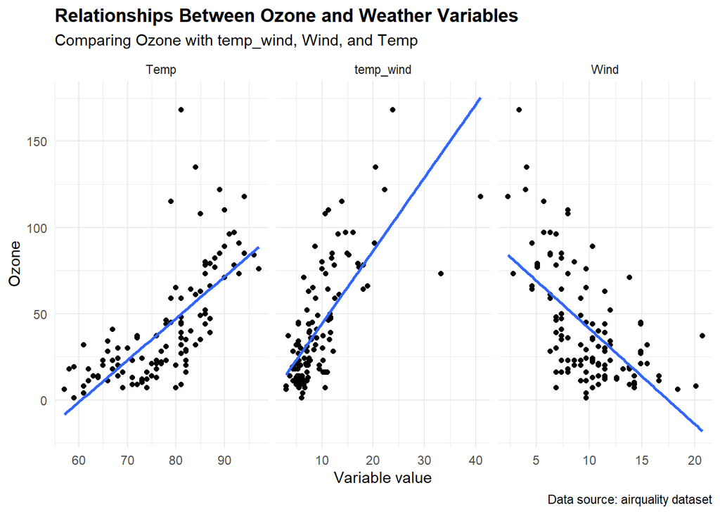

```r
# Visualize the three relationships in one faceted chart.
air_relationships |>
  ggplot(aes(x = value, y = Ozone)) +
  geom_point() +
  geom_smooth(method = "lm", se = FALSE) +
  facet_wrap(~ variable, scales = "free_x") +
  labs(
    title = "Relationships Between Ozone and Weather Variables",
    subtitle = "Comparing Ozone with temp_wind, Wind, and Temp",
    x = "Variable value",
    y = "Ozone",
    caption = "Data source: airquality dataset"
  ) +
  theme_minimal() +
  theme(
    plot.title = element_text(face = "bold")
  )
```

Based on the charts, Ozone appears to increase as temperature increases and generally decreases as wind speed increases. The `temp_wind` variable combines both measurements, so its relationship with Ozone looks a little stronger than either variable by itself. These are visual patterns from the data and don’t necessarily imply cause and effect.